# Conjoint Analysis: Toy Horse Product Line Design

Team 15

2/9/2020

```r
# Loading packages and the toy horse data
rm (list = ls())
require("cluster")
require("fpc")
require("factoextra")
require("gridExtra")
library(cluster)
library(fpc)
library(factoextra)
library(gridExtra)
library(conjoint)

dir= 'C:/Users/annah/1 Rochester/Spring A/Analytics design/HW/HW3 Toy horse'
setwd(dir)
load("GBA424 - Toy Horse Case Data.rdata")
```

##### Part A.Getting Individual Part-Utilities using Linear Regression

```r
#data cleaning: drop rows with NA
conjointData1 = conjointData[complete.cases(conjointData), ]
conjointDataNA <- conjointData[is.na(conjointData$ratings),]

#create a dataframe and fill each individual's part-utilities
coef <- data.frame(ID = rep(NA, 200), intercept = rep(NA,200),
                   price_119.99 = rep(NA,200), size_26 = rep(NA,200), motion_rock = rep(NA,200),
                   style_glam = rep(NA,200))
for(i in 1:200) {
  a = lm(ratings~price+size+motion+style, data = subset(conjointData1, ID==i))
  coef[i,1] = i
  coef[i,2:6] = a$coefficient[1:5]
  coef
}
```

```r
#predict for missing profiles 3,6,10,16
for (i in 1:200){
  for (j in c(3,6,10,16)){
    conjointDataNA[conjointDataNA$ID == i & conjointDataNA$profile == j, 3] =
      coef[i,2] +
      conjointDataNA[conjointDataNA$ID == i & conjointDataNA$profile == j, 4] * coef[i,3] +
      conjointDataNA[conjointDataNA$ID == i & conjointDataNA$profile == j, 5] * coef[i,4] +
      conjointDataNA[conjointDataNA$ID == i & conjointDataNA$profile == j, 6] * coef[i,5] +
      conjointDataNA[conjointDataNA$ID == i & conjointDataNA$profile == j, 7] * coef[i,6]
  }
}
```

```r
#merge and reorder the dataframe by ID and profile
conjointData_full <-rbind(conjointDataNA, conjointData1)
conjointData_full <-conjointData_full[order(conjointData_full$ID, conjointData_full$profile),]
```

###### Part B.Benefit Segmentation via Cluster Analysis

```r
##Evaluate number of clusters to use on data with visualizations
clustTest = function(toClust,print=TRUE,scale=TRUE,maxClusts=15,seed=12345,nstart=20,iter.max=100){
  if(scale){ toClust = scale(toClust);}
  set.seed(seed);   # set random number seed before doing cluster analysis
  wss <- (nrow(toClust)-1)*sum(apply(toClust,2,var))
  for (i in 2:maxClusts) wss[i] <- sum(kmeans(toClust,centers=i,nstart=nstart,iter.max=iter.max)$withinss)
  ##gpw essentially does the following plot using wss above.
  #plot(1:maxClusts, wss, type="b", xlab="Number of Clusters",ylab="Within groups sum of squares")
  gpw = fviz_nbclust(toClust,kmeans,method="wss",iter.max=iter.max,nstart=nstart,k.max=maxClusts) #alternative way to get wss elbow chart.
  pm1 = pamk(toClust,scaling=TRUE)
  ## pm1$nc indicates the optimal number of clusters based on
  ## lowest average silhoutte score (a measure of quality of clustering)
  #alternative way that presents it visually as well.
  gps = fviz_nbclust(toClust,kmeans,method="silhouette",iter.max=iter.max,nstart=nstart,k.max=maxClusts)
  if(print){
    grid.arrange(gpw,gps, nrow = 1)
  }
  list(wss=wss,pm1=pm1$nc,gpw=gpw,gps=gps)
}
```

```r
## Runs a set of clusters as kmeans
runClusts = function(toClust,nClusts,print=TRUE,maxClusts=15,seed=12345,nstart=20,iter.max=100){
  if(length(nClusts)>4){
    warning("Using only first 4 elements of nClusts.")
  }
  kms=list(); ps=list();
  for(i in 1:length(nClusts)){
    kms[[i]] = kmeans(toClust,nClusts[i],iter.max = iter.max, nstart=nstart)
    ps[[i]] = fviz_cluster(kms[[i]], geom = "point", data = toClust) + ggtitle(paste("k =",nClusts[i]))

  }
  library(gridExtra)
  if(print){
    tmp = marrangeGrob(ps, nrow = 2,ncol=2)
    print(tmp)
  }
  list(kms=kms,ps=ps)
}
```

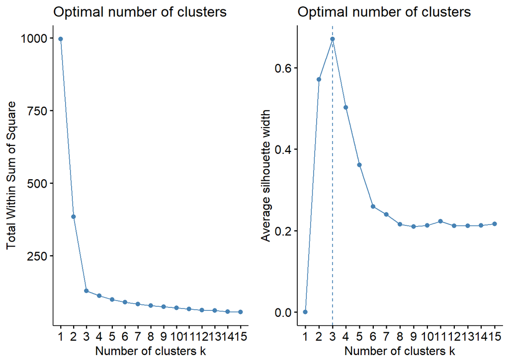

```r
##  pie chart with membership percentages
##  ellipse plot that indicates cluster definitions against principle components
##  barplot of the cluster means
plotClust = function(km,toClust,discPlot=FALSE){
  nc = length(km$size)
  if(discPlot){par(mfrow=c(2,2))}
  else {par(mfrow=c(3,1))}
  percsize = paste(1:nc," = ",format(km$size/sum(km$size)*100,digits=2),"%",sep="")
  pie(km$size,labels=percsize,col=1:nc)

  clusplot(toClust, km$cluster, color=TRUE, shade=TRUE,
           labels=2, lines=0,col.clus=1:nc); #plot clusters against principal components

  if(discPlot){
    plotcluster(toClust, km$cluster,col=km$cluster); #plot against discriminant functions ()
  }
  rng = range(km$centers)
  dist = rng[2]-rng[1]
  locs = km$centers+.05*dist*ifelse(km$centers>0,1,-1)
  bm = barplot(km$centers,beside=TRUE,col=1:nc,main="Cluster Means",ylim=rng+dist*c(-.1,.1))
  text(bm,locs,formatC(km$centers,format="f",digits=1))
}

partworth = coef[2:6]

checks = clustTest(partworth,print=TRUE,scale=TRUE,maxClusts=15,seed=12345,nstart=20,iter.max=100)
```

```r
clusts = runClusts(partworth,c(2,3,4,9),print=TRUE,maxClusts=15,seed=12345,nstart=20,iter.max=100)
```

[figure not shown]

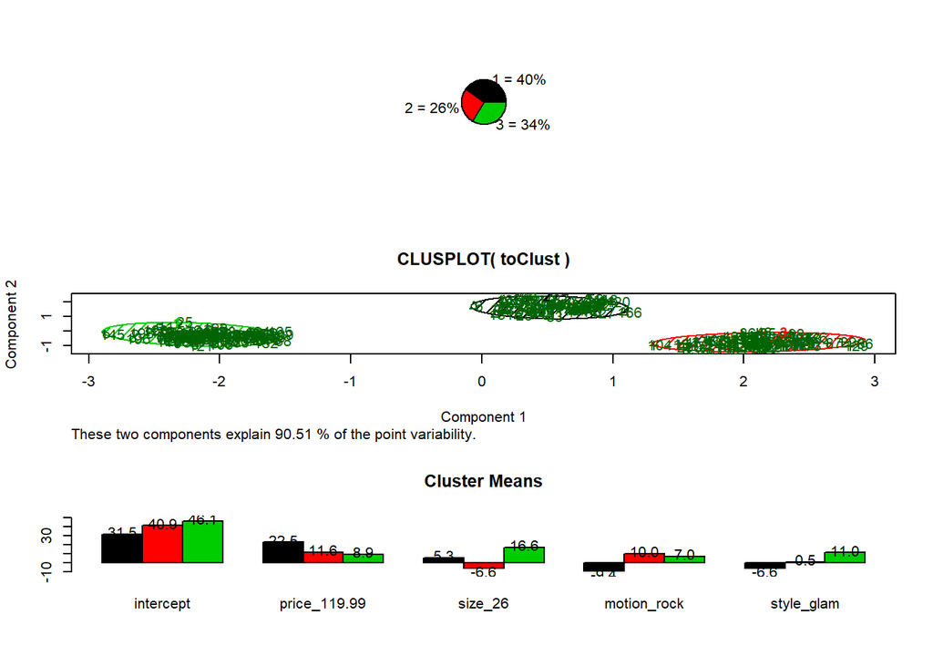

```r
plotClust(clusts[[1]][[2]],partworth)
```

We tried four different cluster schemes with 2 clusters, 3 clusters, 4 clusters, and 9 clusters. According to the two plots that show the optimal number of clusters, we can know that the optimal number of clusters is 3. Elbow rule suggests around 3 clusters, focal points at 3 clusters as well. First segment (black)：care about the price most;prefer 26 inches ; prefer bouncing the most; prefer racing the most —- Profile 4 Second segment (red): prefer low price; likes 18-inch one the most; prefer rocking the most; prefer glamorous —- Profile 14 Third segment (green): care about the size most; they are the least price sensitive; prefer 26-inch the most; prefer rocking motion; prefer glamorous the most. —- Profile 16

##### Part C. A Priori segmentation using Age and Gender

```r
# Create a dataframe to combine conjoint data with demographics data
conjointDemo <- merge(conjointData1, respondentData, by = 'ID')
# Without Segmentation
summary(lm(ratings~price+size+motion+style, data = conjointDemo))
```

```
##
## Call:
## lm(formula = ratings ~ price + size + motion + style, data = conjointDemo)
##
## Residuals:
##     Min      1Q  Median      3Q     Max
## -41.254 -13.303  -1.287  12.771  44.221
##
## Coefficients:
##             Estimate Std. Error t value Pr(>|t|)
## (Intercept)  38.8906     0.7666  50.732   <2e-16 ***
## price        15.0490     0.7183  20.950   <2e-16 ***
## size          5.9594     0.6877   8.665   <2e-16 ***
## motion        1.2200     0.6877   1.774   0.0762 .
## style         1.1434     0.6877   1.663   0.0965 .
## ---
## Signif. codes:  0 '***' 0.001 '**' 0.01 '*' 0.05 '.' 0.1 ' ' 1
##
## Residual standard error: 16.59 on 2395 degrees of freedom
## Multiple R-squared:  0.2011, Adjusted R-squared:  0.1998
## F-statistic: 150.7 on 4 and 2395 DF,  p-value: < 2.2e-16
```

Price is the most influential attribute; style is the least influential attribute Importance: price > size > motion > style — Profile 16

## A Priori Segmentation using age and gender (seperately)

```r
#age = 0: 2 years old
age0 = lm(ratings~price+size+motion+style, data = subset(conjointDemo, age == 0))
summary(age0)
```

```
##
## Call:
## lm(formula = ratings ~ price + size + motion + style, data = subset(conjointDemo,
##     age == 0))
##
## Residuals:
##     Min      1Q  Median      3Q     Max
## -43.528 -11.312  -0.598   9.857  43.040
##
## Coefficients:
##             Estimate Std. Error t value Pr(>|t|)
## (Intercept)  39.5462     1.0164  38.909  < 2e-16 ***
## price        14.4133     0.9524  15.134  < 2e-16 ***
## size          3.8532     0.9118   4.226 2.57e-05 ***
## motion        2.7950     0.9118   3.065  0.00222 **
## style         1.1867     0.9118   1.301  0.19338
## ---
## Signif. codes:  0 '***' 0.001 '**' 0.01 '*' 0.05 '.' 0.1 ' ' 1
##
## Residual standard error: 15.47 on 1183 degrees of freedom
## Multiple R-squared:  0.1912, Adjusted R-squared:  0.1884
## F-statistic:  69.9 on 4 and 1183 DF,  p-value: < 2.2e-16
```

For children whose age is 2 years, prefer the lower price ($119.99). Comparing to children who are 3-4 years old, they also care less about size and prefer 26-inches. They also prefer rocking motion and glamorous style. — Profile 16

```r
#age = 1: 3-4 years old
age1 = lm(ratings~price+size+motion+style, data = subset(conjointDemo, age == 1))
summary(age1)
```

```
##
## Call:
## lm(formula = ratings ~ price + size + motion + style, data = subset(conjointDemo,
##     age == 1))
##
## Residuals:
##     Min      1Q  Median      3Q     Max
## -37.465 -14.368  -2.484  15.008  44.386
##
## Coefficients:
##             Estimate Std. Error t value Pr(>|t|)
## (Intercept)  38.2480     1.1400  33.549  < 2e-16 ***
## price        15.6721     1.0683  14.671  < 2e-16 ***
## size          8.0239     1.0228   7.845 9.47e-15 ***
## motion       -0.3238     1.0228  -0.317    0.752
## style         1.1010     1.0228   1.076    0.282
## ---
## Signif. codes:  0 '***' 0.001 '**' 0.01 '*' 0.05 '.' 0.1 ' ' 1
##
## Residual standard error: 17.53 on 1207 degrees of freedom
## Multiple R-squared:  0.2185, Adjusted R-squared:  0.2159
## F-statistic: 84.37 on 4 and 1207 DF,  p-value: < 2.2e-16
```

For children whose age is around 3-4 years, they care about style more than motion and they prefer bouncing motion more than rocking. —- Profile 12

```r
#gender = 0: boy
gender0 = lm(ratings~price+size+motion+style, data = subset(conjointDemo, gender == 0))
summary(gender0)
```

```
##
## Call:
## lm(formula = ratings ~ price + size + motion + style, data = subset(conjointDemo,
##     gender == 0))
##
## Residuals:
##     Min      1Q  Median      3Q     Max
## -33.917 -10.607  -2.351   7.762  47.017
##
## Coefficients:
##             Estimate Std. Error t value Pr(>|t|)
## (Intercept)  36.5668     0.9821  37.233  < 2e-16 ***
## price        16.8573     0.9203  18.318  < 2e-16 ***
## size          3.8509     0.8811   4.371 1.36e-05 ***
## motion       -0.7601     0.8811  -0.863   0.3885
## style        -1.8895     0.8811  -2.145   0.0322 *
## ---
## Signif. codes:  0 '***' 0.001 '**' 0.01 '*' 0.05 '.' 0.1 ' ' 1
##
## Residual standard error: 14.41 on 1099 degrees of freedom
## Multiple R-squared:  0.2862, Adjusted R-squared:  0.2836
## F-statistic: 110.2 on 4 and 1099 DF,  p-value: < 2.2e-16
```

For boys, they care about style more than motion. They prefer bouncing motion and prefer racing tyle. —- profile 4

```r
#gender = 1: girl
gender1 = lm(ratings~price+size+motion+style, data = subset(conjointDemo, gender == 1))
summary(gender1)
```

```
##
## Call:
## lm(formula = ratings ~ price + size + motion + style, data = subset(conjointDemo,
##     gender == 1))
##
## Residuals:
##     Min      1Q  Median      3Q     Max
## -45.675 -13.646   2.716  12.948  36.175
##
## Coefficients:
##             Estimate Std. Error t value Pr(>|t|)
## (Intercept)  40.8701     1.0580  38.630  < 2e-16 ***
## price        13.5086     0.9914  13.626  < 2e-16 ***
## size          7.7555     0.9492   8.171 7.24e-16 ***
## motion        2.9068     0.9492   3.062  0.00224 **
## style         3.7270     0.9492   3.927 9.07e-05 ***
## ---
## Signif. codes:  0 '***' 0.001 '**' 0.01 '*' 0.05 '.' 0.1 ' ' 1
##
## Residual standard error: 16.82 on 1291 degrees of freedom
## Multiple R-squared:  0.1902, Adjusted R-squared:  0.1877
## F-statistic: 75.82 on 4 and 1291 DF,  p-value: < 2.2e-16
```

For male and female, they all want lower price and 26-inches. However, comparing to female, male care more about price, female care more about size. they all care about style more than motion, but male prefer bouncing motion and racing style, while female prefer rocking motion and glamour style.

## A Priori Segmentation using age and gender (combined)

```r
#age = 0, gender = 0, 2 year-old boy
age0gender0 = lm(ratings~price+size+motion+style, data = subset(conjointDemo, age == 0 & gender == 0))
summary(age0gender0)
```

```
##
## Call:
## lm(formula = ratings ~ price + size + motion + style, data = subset(conjointDemo,
##     age == 0 & gender == 0))
##
## Residuals:
##     Min      1Q  Median      3Q     Max
## -38.489  -9.927  -0.726   8.019  43.934
##
## Coefficients:
##             Estimate Std. Error t value Pr(>|t|)
## (Intercept)  37.7780     1.2840  29.422   <2e-16 ***
## price        15.3906     1.2032  12.792   <2e-16 ***
## size          2.3625     1.1520   2.051   0.0407 *
## motion        1.6932     1.1520   1.470   0.1421
## style        -0.9823     1.1520  -0.853   0.3941
## ---
## Signif. codes:  0 '***' 0.001 '**' 0.01 '*' 0.05 '.' 0.1 ' ' 1
##
## Residual standard error: 14.17 on 619 degrees of freedom
## Multiple R-squared:  0.2376, Adjusted R-squared:  0.2326
## F-statistic: 48.22 on 4 and 619 DF,  p-value: < 2.2e-16
```

```r
#age = 0, gender = 1, 2 year-old girl
age0gender1 = lm(ratings~price+size+motion+style, data = subset(conjointDemo, age == 0 & gender == 1))
summary(age0gender1)
```

```
##
## Call:
## lm(formula = ratings ~ price + size + motion + style, data = subset(conjointDemo,
##     age == 0 & gender == 1))
##
## Residuals:
##     Min      1Q  Median      3Q     Max
## -42.866 -11.811   1.396  11.505  35.816
##
## Coefficients:
##             Estimate Std. Error t value Pr(>|t|)
## (Intercept)   41.502      1.495  27.765  < 2e-16 ***
## price         13.332      1.401   9.518  < 2e-16 ***
## size           5.502      1.341   4.103 4.68e-05 ***
## motion         4.014      1.341   2.993  0.00288 **
## style          3.586      1.341   2.674  0.00771 **
## ---
## Signif. codes:  0 '***' 0.001 '**' 0.01 '*' 0.05 '.' 0.1 ' ' 1
##
## Residual standard error: 15.68 on 559 degrees of freedom
## Multiple R-squared:  0.186,  Adjusted R-squared:  0.1802
## F-statistic: 31.93 on 4 and 559 DF,  p-value: < 2.2e-16
```

```r
#age = 1, gender = 0, 3-4 year-old boy
age1gender0 = lm(ratings~price+size+motion+style, data = subset(conjointDemo, age == 1 & gender == 0))
summary(age1gender0)
```

```
##
## Call:
## lm(formula = ratings ~ price + size + motion + style, data = subset(conjointDemo,
##     age == 1 & gender == 0))
##
## Residuals:
##     Min      1Q  Median      3Q     Max
## -23.768  -9.114  -4.004   4.380  49.241
##
## Coefficients:
##             Estimate Std. Error t value Pr(>|t|)
## (Intercept)   34.992      1.468  23.840  < 2e-16 ***
## price         18.764      1.375  13.643  < 2e-16 ***
## size           5.786      1.317   4.394 1.37e-05 ***
## motion        -3.949      1.317  -2.999  0.00285 **
## style         -3.069      1.317  -2.331  0.02020 *
## ---
## Signif. codes:  0 '***' 0.001 '**' 0.01 '*' 0.05 '.' 0.1 ' ' 1
##
## Residual standard error: 14.2 on 475 degrees of freedom
## Multiple R-squared:  0.3758, Adjusted R-squared:  0.3706
## F-statistic:  71.5 on 4 and 475 DF,  p-value: < 2.2e-16
```

```r
#age = 1, gender = 1, 3-4 year-old girl
age1gender1 = lm(ratings~price+size+motion+style, data = subset(conjointDemo, age == 1 & gender == 1))
summary(age1gender1)
```

```
##
## Call:
## lm(formula = ratings ~ price + size + motion + style, data = subset(conjointDemo,
##     age == 1 & gender == 1))
##
## Residuals:
##     Min      1Q  Median      3Q     Max
## -46.179 -14.856   3.495  13.827  35.671
##
## Coefficients:
##             Estimate Std. Error t value Pr(>|t|)
## (Intercept)   40.383      1.476  27.353  < 2e-16 ***
## price         13.645      1.383   9.863  < 2e-16 ***
## size           9.491      1.325   7.166  1.9e-12 ***
## motion         2.054      1.325   1.550   0.1215
## style          3.835      1.325   2.896   0.0039 **
## ---
## Signif. codes:  0 '***' 0.001 '**' 0.01 '*' 0.05 '.' 0.1 ' ' 1
##
## Residual standard error: 17.64 on 727 degrees of freedom
## Multiple R-squared:  0.1986, Adjusted R-squared:  0.1941
## F-statistic: 45.03 on 4 and 727 DF,  p-value: < 2.2e-16
```

```r
## Statistical Significance test
#base on gender
summary(lm(ratings~price+size+motion+style+gender:price+gender:size+gender:motion+gender:style, data = conjointDemo))
```

```
##
## Call:
## lm(formula = ratings ~ price + size + motion + style + gender:price +
##     gender:size + gender:motion + gender:style, data = conjointDemo)
##
## Residuals:
##     Min      1Q  Median      3Q     Max
## -46.158 -11.764  -0.196  11.583  47.584
##
## Coefficients:
##               Estimate Std. Error t value Pr(>|t|)
## (Intercept)    38.8906     0.7295  53.309  < 2e-16 ***
## price          15.8372     0.9463  16.736  < 2e-16 ***
## size            3.1141     0.9319   3.342 0.000845 ***
## motion         -1.8370     0.8928  -2.058 0.039739 *
## style          -2.9664     0.8928  -3.323 0.000905 ***
## price:gender   -1.4596     1.2117  -1.205 0.228513
## size:gender     5.2690     1.2285   4.289 1.87e-05 ***
## motion:gender   5.6611     1.1245   5.035 5.15e-07 ***
## style:gender    7.6107     1.1245   6.768 1.63e-11 ***
## ---
## Signif. codes:  0 '***' 0.001 '**' 0.01 '*' 0.05 '.' 0.1 ' ' 1
##
## Residual standard error: 15.79 on 2391 degrees of freedom
## Multiple R-squared:  0.2777, Adjusted R-squared:  0.2753
## F-statistic: 114.9 on 8 and 2391 DF,  p-value: < 2.2e-16
```

```r
#base on age
summary(lm(ratings~price+size+motion+style+age:price+age:size+age:motion+age:style, data = conjointDemo))
```

```
##
## Call:
## lm(formula = ratings ~ price + size + motion + style + age:price +
##     age:size + age:motion + age:style, data = conjointDemo)
##
## Residuals:
##    Min     1Q Median     3Q    Max
## -43.48 -12.91  -1.25  12.63  44.54
##
## Coefficients:
##             Estimate Std. Error t value Pr(>|t|)
## (Intercept)  38.8906     0.7645  50.868  < 2e-16 ***
## price        14.7011     0.9602  15.311  < 2e-16 ***
## size          4.0610     0.9436   4.304 1.75e-05 ***
## motion        3.0988     0.9068   3.417 0.000643 ***
## style         1.4905     0.9068   1.644 0.100391
## price:age     0.6889     1.2659   0.544 0.586353
## size:age      3.7591     1.2833   2.929 0.003431 **
## motion:age   -3.7204     1.1747  -3.167 0.001559 **
## style:age    -0.6873     1.1747  -0.585 0.558537
## ---
## Signif. codes:  0 '***' 0.001 '**' 0.01 '*' 0.05 '.' 0.1 ' ' 1
##
## Residual standard error: 16.54 on 2391 degrees of freedom
## Multiple R-squared:  0.2067, Adjusted R-squared:  0.2041
## F-statistic: 77.88 on 8 and 2391 DF,  p-value: < 2.2e-16
```

- The interaction between price and gender is not statistically significant, which means that the difference between price’s effect on boy and girl groups’ utilities is not significant— we may not care much about price’s impact on different gender groups.
- The interaction effect between age and price, as well as between style and age is statistically insignificant.
- Compared to age, gender is a more significant segmentation factor according to the P-value of interacting terms (significant results on three out of four attributes).

```r
# Create a dataframe and fill in the summary of part-utilities of different segments within A Priori Segmentation
coefDemo <- data.frame(demo = rep(NA, 8), intercept = rep(NA,8),
                   price_119.99 = rep(NA,8), size_26 = rep(NA,8), motion_rock = rep(NA,8),
                   style_glam = rep(NA,8))
rownames(coefDemo) = c('age0','age1','gender0','gender1','age0gender0','age0gender1','age1gender0','age1gender1')
coefDemo[1,2:6] = age0$coefficients
coefDemo[2,2:6] = age1$coefficients
coefDemo[3,2:6] = gender0$coefficients
coefDemo[4,2:6] = gender1$coefficients
coefDemo[5,2:6] = age0gender0$coefficients
coefDemo[6,2:6] = age0gender1$coefficients
coefDemo[7,2:6] = age1gender0$coefficients
coefDemo[8,2:6] = age1gender1$coefficients
coefDemo[,1] = rownames(coefDemo)

coefDemo
```

```
##                    demo intercept price_119.99  size_26 motion_rock
## age0               age0  39.54618     14.41329 3.853159   2.7949992
## age1               age1  38.24797     15.67213 8.023919  -0.3238099
## gender0         gender0  36.56684     16.85734 3.850932  -0.7601191
## gender1         gender1  40.87007     13.50856 7.755489   2.9067692
## age0gender0 age0gender0  37.77803     15.39062 2.362458   1.6932061
## age0gender1 age0gender1  41.50244     13.33199 5.502446   4.0140043
## age1gender0 age1gender0  34.99230     18.76409 5.785949  -3.9494419
## age1gender1 age1gender1  40.38284     13.64461 9.491441   2.0536536
##             style_glam
## age0         1.1866709
## age1         1.1009752
## gender0     -1.8895287
## gender1      3.7269958
## age0gender0 -0.9823353
## age0gender1  3.5864224
## age1gender0 -3.0688800
## age1gender1  3.8353065
```